# How life expectancy has changed across continents and worldwide

Version 1 — Descriptive analysis | 1952–2025

# 1 Context and data import

We are examining how average life expectancy has changed on each continent and worldwide. We are expanding the scope of the original study of **Gapminder** sample to cover **every year from 1952 to 2025**, keeping the **142 countries and the same six columns**.

The accompanying script shows how we have combined time series of life expectancy, population, and GDP per capita

```r
library(tidyverse)

if (file.exists("gapminder_1952_2025.rds")) {
  gapminder <- readRDS("gapminder_1952_2025.rds")
} else if (file.exists("gapminder_1952_2025.csv")) {
  gapminder <- readr::read_csv("gapminder_1952_2025.csv", show_col_types = FALSE)
} else {
  source("carica_gapminder_1952_2025.R", local = knitr::knit_global())
}

stopifnot(
  identical(names(gapminder), c("country", "continent", "year",
                                "lifeExp", "pop", "gdpPercap")),
  n_distinct(gapminder$country) == 142L,
  n_distinct(gapminder$continent) == 5L,
  identical(sort(unique(as.integer(gapminder$year))), 1952:2025),
  !anyDuplicated(gapminder[c("country", "year")])
)

knitr::kable(
  gapminder |>
    filter(country == "Afghanistan", year %in% c(1952, 1953, 2024, 2025)),
  digits = 2, caption = "Annual Gapminder sample: selected rows from 1952–2025"
)
```

Annual Gapminder sample: selected rows from 1952–2025

| country | continent | year | lifeExp | pop | gdpPercap |
| --- | --- | --- | --- | --- | --- |
| Afghanistan | Asia | 1952 | 43.14 | 7987783 | 1382 |
| Afghanistan | Asia | 1953 | 43.45 | 8096698 | 1441 |
| Afghanistan | Asia | 2024 | 64.89 | 42647492 | 2069 |
| Afghanistan | Asia | 2025 | 65.17 | 43844111 | 2103 |

# 2 1. Computing life expectancy for a continent

$$\boxed{LE_{C,t}=\frac{\sum_{i\in C}lifeExp_{i,t}\,pop_{i,t}}
{\sum_{i\in C}pop_{i,t}}}$$

Therefore, a country with a larger population accounts for a larger share of the continent’s total population. In R, we use `weighted.mean(lifeExp, w = pop)`.

# 3 2. Life expectancy across continents

```r
valid_data <- gapminder |>
  filter(is.finite(lifeExp), is.finite(pop), pop > 0)

continent_le <- valid_data |>
  group_by(continent, year) |>
  summarise(lifeExp = weighted.mean(lifeExp, w = pop), .groups = "drop")

stopifnot(nrow(continent_le) == 5L * 74L)
```

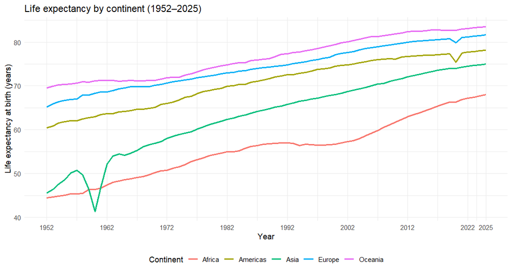

Population-weighted life expectancy by continent, 1952–2025.

```r
ggplot(continent_le, aes(year, lifeExp, color = continent)) +
  geom_line(linewidth = 1.1) +
  scale_x_continuous(breaks = c(seq(1952, 2022, 10), 2025)) +
  labs(title = "Life expectancy by continent (1952–2025)",
       x = "Year", y = "Life expectancy at birth (years)",
       color = "Continent") +
  theme_minimal(base_size = 12) +
  theme(legend.position = "bottom")
```

```r
comparison <- continent_le |>
  filter(year %in% c(1952, 2025)) |>
  pivot_wider(names_from = year, values_from = lifeExp, names_prefix = "LE_") |>
  mutate(change = LE_2025 - LE_1952) |>
  arrange(desc(change))

knitr::kable(comparison, digits = 2,
  col.names = c("Continent", "1952 (years)", "2025 (years)", "Change (years)"),
  caption = "Change in population-weighted life expectancy, 1952–2025")
```

Change in population-weighted life expectancy, 1952–2025

| Continent | 1952 (years) | 2025 (years) | Change (years) |
| --- | --- | --- | --- |
| Asia | 45.51 | 74.97 | 29.46 |
| Africa | 44.41 | 67.97 | 23.57 |
| Americas | 60.40 | 78.18 | 17.78 |
| Europe | 65.16 | 81.66 | 16.50 |
| Oceania | 69.55 | 83.54 | 13.99 |

Every continent in the sample has gained years of life expectancy, but not at the same pace. The average life expectancy has increased on all continents studied, although the rate of increase varies. **Asia** and **Africa** shows the largest increase respectively (**29.46 years**), (**23.57 years**) . America and Europe increase their pace for + 18y, and +17y, Instead Oceania is last, even having the highest seniority 83,5y.